# HW 7

Data 180, Professor Kennedy

Sanskriti Rijal

rijals@dickinson.edu

December 05, 2023

**Due date:** December 4 beginning of class.

In this homework, we will analyze news headlines data scraped from abcnews, posted on Github in a csv file named `news.csv`.

Read the `news.csv` into R and create the object `news` using

```r
#library(tidyverse)
library(tm)
news<-read.csv("/Users/sanskriti/Desktop/DATA-180-Sanskriti/hw7/news.csv",header=T)
```

Read also the positive and negative word dictionaries, both found on Github. This will later come in handy:

```r
posWords <- scan("/Users/sanskriti/Desktop/DATA-180-Sanskriti/hw7/positive-words.txt", character(0), sep = "\n")  # 2006 items
negWords <- scan("/Users/sanskriti/Desktop/DATA-180-Sanskriti/hw7/negative-words.txt", character(0), sep = "\n")  # 4783 items
head(posWords,15)
```

```
##  [1] "a+"            "abound"        "abounds"       "abundance"
##  [5] "abundant"      "accessable"    "accessible"    "acclaim"
##  [9] "acclaimed"     "acclamation"   "accolade"      "accolades"
## [13] "accommodative" "accomodative"  "accomplish"
```

```r
head(negWords,15)
```

```
##  [1] "2-faced"     "2-faces"     "abnormal"    "abolish"     "abominable"
##  [6] "abominably"  "abominate"   "abomination" "abort"       "aborted"
## [11] "aborts"      "abrade"      "abrasive"    "abrupt"      "abruptly"
```

# Question 1

First, check how many years of news data we have loaded in in R.

```r
library(dplyr)
years <- unique(news$year)
print(years)
```

```
##  [1] 2021 2009 2011 2017 2006 2008 2007 2010 2005 2012 2018 2014 2015 2019 2013
## [16] 2020 2016 2003 2004
```

# Question 2

Store the headlines column in a vector of text named `charVector`. Print the first 6 entries in the vector.

```r
charVector <- news$headline_text
print(head(charVector,6))
```

```
## [1] "people flock to kabul airport as taliban seizes capital"
## [2] "senior liberals desert turnbull"
## [3] "interview matt scott"
## [4] "one plus one: jim cassidy"
## [5] "more australians leave lebanon"
## [6] "melb housing plan released"
```

# Question 3

Convert `charVector` into a vector source object named `wordVector` using the function `VectorSource()`. (See class notes on how to do this) Then convert `wordVector` into a corpus object named `wordCorpus` using the function `Corpus()`.

```r
wordVector <- VectorSource(charVector)
wordCorpus <- Corpus(wordVector)
print(wordCorpus)
```

```
## <<SimpleCorpus>>
## Metadata:  corpus specific: 1, document level (indexed): 0
## Content:  documents: 10000
```

# Question 4

We are now ready to do some basic trimming on the text. Do the following on the `wordCorpus` object using the `tm_map()` function, and print what’s left of the first paragraph after trimming. (Note: ignore warnings.) * Make all text lowercase * Remove punctuation * Remove numbers * Remove stopwords (e.g., the, a, at, etc.)

```r
customFunct <- function(text) {
  text <- tolower(text)
  text <- removePunctuation(text)
  text <- removeNumbers(text)
  text <- removeWords(text,stopwords("english"))
  return(text)
}
wordCorpus <- tm_map(wordCorpus, content_transformer(customFunct))
print(content(wordCorpus)[1])
```

```
## [1] "people flock  kabul airport  taliban seizes capital"
```

# Question 5

What is a term document matrix? Explain. Create a term document matrix from the news vector and store it as an object named `tdm` using the function `TermDocumentMatrix`. Term document matrix is a mathematical matrix that represents the frequency of words or terms.

```r
tdm <- TermDocumentMatrix(wordCorpus)
print(tdm)
```

```
## <<TermDocumentMatrix (terms: 12394, documents: 10000)>>
## Non-/sparse entries: 52623/123887377
## Sparsity           : 100%
## Maximal term length: 17
## Weighting          : term frequency (tf)
```

# Question 6

Convert `tdm` into a matrix named `m`. Store the frequency of occurrence of each word in the news headlines in an object named `wordCounts`. Return the top 10 most frequent words. (Note: if you run into memory issues creating the matrix `m`, try using one of the computers in Tome.)

```r
m <- as.matrix(tdm)
wordCounts <- rowSums(m)
sorted <- sort(wordCounts, decreasing = TRUE)
top <- head(sorted,10)
print(top)
```

```
##     police        man        new       says      court  australia    council
##        338        251        241        176        159        141        138
##       fire australian       govt
##        132        126        123
```

# Question 7

Create a barplot of the words that showed up at least 50 times in the news headlines. Rotate the x axis labels by 90 degrees, and decrease the label font size by 25%.

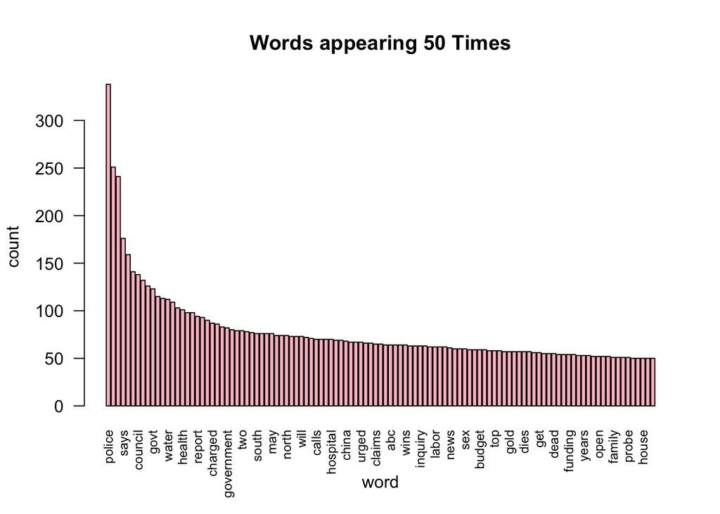

```r
topWordCount <- wordCounts[wordCounts >= 50]
sorted <- sort(topWordCount, decreasing = TRUE)
barplot(sorted, col= "pink", main = "Words appearing 50 Times",
xlab = "word", ylab = "count", las = 2, cex.names = 0.75)
```

# Question 8

What is the percentage of positive words in the news headlines? What is the percentage of negative words? Make a barplot for each (for positive and negative words that showed up separately) showing the most frequent words for words that showed up at least 20 times. (Note: don’t forget to get the total number of unique words that showed up in the data.)

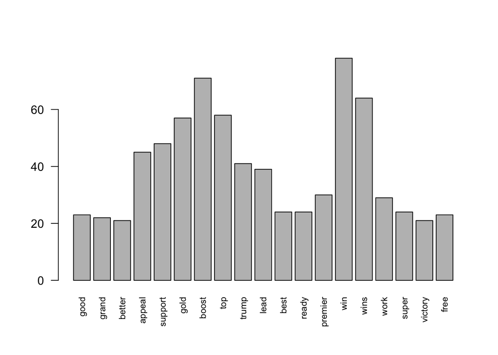

```r
sumWords <- sum(wordCounts)
posMatch <- match(names(wordCounts), posWords, nomatch = 0)
posMatch <- posMatch != 0
posMatch <- wordCounts[posMatch]
barplot(posMatch[posMatch >20], las = 2, cex.names = 0.75)
```

```r
posPercentage <- sum(posMatch) / sumWords
print(posPercentage*100)
```

```
## [1] 3.734345
```

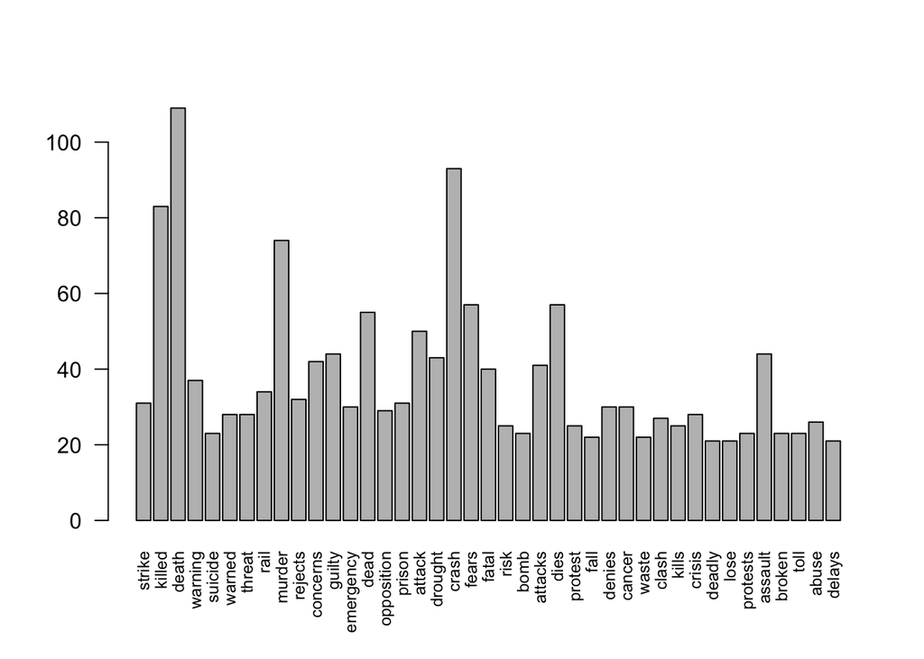

```r
negMatch <- match(names(wordCounts), negWords, nomatch = 0)
negMatch <- negMatch != 0
negMatch <- wordCounts[negMatch]
 barplot(negMatch[negMatch>20],las=2,cex.names=0.75)
```

```r
 print((sum(negMatch)/sumWords)*100)
```

```
## [1] 7.770398
```

Let’s get the number of articles published in each year and month. Note that the chunk below creates two new variables `count` and `yearmonth`:

```r
news <- news %>% group_by(year,month) %>% mutate(count=n(), yearmonth = paste(year, month,sep = '/')) %>% arrange(year,month,day)
```

# Question 9

Using `ggplot2`, create a barplot for the frequency of articles released in each year and month. On the x axis, you should have year month, e.g., 2003/10, 2003/11, 2003/12, 2004/1, on the y-axis you should have the number of articles released in the data. Do you see a change in the number of articles released across years? (Hint: use `factor()` with `levels=` options specified when you call `aes(x=)` to have a proper chronological sorting on your x axis. Use `+theme(axis.text=element_text(size=4,angle=90)` to fit the dates on the x axis.)

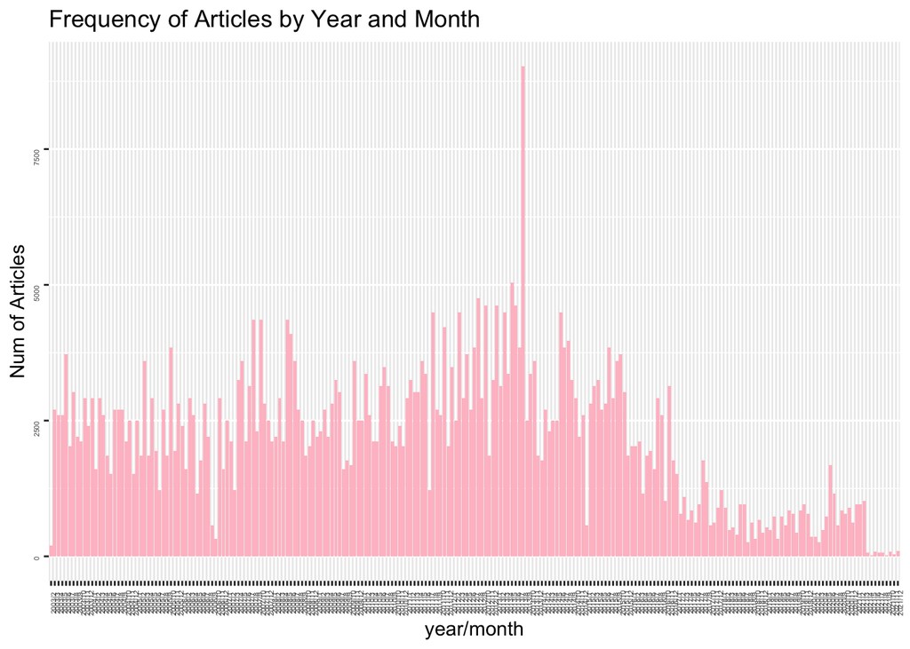

```r
library(ggplot2)
ggplot(news, aes(x=factor(yearmonth, level=unique(yearmonth)), y = count)) +
  geom_bar(stat = 'identity', fill = "pink") +
  labs(title = "Frequency of Articles by Year and Month", x = "year/month", y = "Num of Articles") + theme(axis.text=element_text(size=4,angle=90))
```

Let’s now practice working with `quanteda` and `corpus` packages. Install the packages first if you don’t have them in your computer and load them in in R.

```r
library("quanteda")
```

# Question 10

Using the `term_stats()` function, return the 20 most frequent single words that show up in the data. Make sure to filter out * punctuation * symbols * stopwords

```r
words <-termFreq(charVector, control = list(removePunctuation=TRUE, stopwords=TRUE))
sort(words, decreasing = TRUE)[1:20]
```

```
##     police        man        new       says      court  australia    council
##        338        251        241        176        159        141        138
##       fire australian       govt  interview        nsw      water      death
##        132        126        123        115        113        112        109
##       call     health        qld     sydney     report      crash
##        103        101         98         98         94         93
```

# Question 11

Repeat the previous question for word pairs (frequency of 2 words that show up, instead of 1 word)

```r
library(ngram)
 Twowords <-paste(unlist(charVector), collapse=" ")
 pairs <- ngram(Twowords, n=2)
 head(get.phrasetable(pairs),20)
```

```
##           ngrams freq         prop
## 1         to be    70 0.0010642341
## 2      urged to    54 0.0008209806
## 3     calls for    54 0.0008209806
## 4      call for    51 0.0007753706
## 5        on the    51 0.0007753706
## 6        in the    49 0.0007449639
## 7        of the    48 0.0007297605
## 8     killed in    48 0.0007297605
## 9        out of    46 0.0006993539
## 10 charged over    45 0.0006841505
## 11   accused of    40 0.0006081338
## 12       set to    38 0.0005777271
## 13  man charged    33 0.0005017104
## 14   gold coast    33 0.0005017104
## 15   jailed for    32 0.0004865070
## 16   search for    30 0.0004561003
## 17    world cup    28 0.0004256937
## 18      to help    28 0.0004256937
## 19        to go    27 0.0004104903
## 20       to get    26 0.0003952870
```

# Question 12

Create a corpus object using `corpus()` function. Store it in an object named `newscorpus`. Convert `newscorpus` into paragraphs with `corpus_reshape()`.

```r
newscorpus <- corpus(charVector)
newscorpus <- corpus_reshape(newscorpus, to = "paragraphs")
summary(newscorpus)
```

```
## Corpus consisting of 10000 documents, showing 100 documents:
##
##     Text Types Tokens Sentences
##    text1     9      9         1
##    text2     4      4         1
##    text3     3      3         1
##    text4     5      6         1
##    text5     4      4         1
##    text6     4      4         1
##    text7     7      7         1
##    text8     6      6         1
##    text9     8      8         1
##   text10     5      5         1
##   text11     5      5         1
##   text12     6      6         1
##   text13     6      6         1
##   text14     7      7         1
##   text15     8      8         1
##   text16     9     11         1
##   text17     8      8         1
##   text18     8      8         1
##   text19     8      8         1
##   text20     5      5         1
##   text21     7      7         1
##   text22    10     10         1
##   text23     8      8         1
##   text24     4      4         1
##   text25     8      8         1
##   text26     7      7         1
##   text27     6      6         1
##   text28     9      9         1
##   text29     2      2         1
##   text30     5      5         1
##   text31     7      7         1
##   text32     5      5         1
##   text33     7      7         1
##   text34     6      6         1
##   text35     7      7         1
##   text36     8      8         1
##   text37     7      7         1
```

[output cut: 48 more lines]

```
##   text86     6      6         1
##   text87     8      8         1
##   text88     6      6         1
##   text89     5      5         1
##   text90     7      7         1
##   text91     3      3         1
##   text92     5      5         1
##   text93     8      9         1
##   text94     8      8         1
##   text95     9      9         1
##   text96     6      6         1
##   text97     8      8         1
##   text98     8      8         1
##   text99     8      8         1
##  text100     8      8         1
```

# Question 13

Create a term document matrix named `news_dtm` by using the `dfm()` function. While you call `dfm()`, make sure to clean the paragraphs by keeping only the stems of the words, removing punctuations, removing symbols, removing numbers, and removing stopwords. If you wish to get rid of anything that does not look correct in the data (such as weird bunch of characters that show up as “words”) you may trim them out at this stage using `dfm_remove()`. Finally, trim `news_dtm` such that it contains only words that show up at least 50 times. Print the first 6 rows of `news_dtm`. (Note: Again, ignore warnings.)

```r
news_dtm <- dfm(newscorpus,
 tolower = TRUE, remove_punct = TRUE, remove_symbols = TRUE, remove_numbers = TRUE, remove = stopwords("english"), stem = TRUE)
news <- dfm_remove(news_dtm,c(':', '=', 'nt','mp'))
news <- dfm_trim(news_dtm, min_termfreq=50)
head(news_dtm)
```

```
## Document-feature matrix of: 6 documents, 9,481 features (99.96% sparse) and 0 docvars.
##        features
## docs    peopl flock kabul airport taliban seiz capit senior liber desert
##   text1     1     1     1       1       1    1     1      0     0      0
##   text2     0     0     0       0       0    0     0      1     1      1
##   text3     0     0     0       0       0    0     0      0     0      0
##   text4     0     0     0       0       0    0     0      0     0      0
##   text5     0     0     0       0       0    0     0      0     0      0
##   text6     0     0     0       0       0    0     0      0     0      0
## [ reached max_nfeat ... 9,471 more features ]
```

# Question 14

Create a wordcloud of `news_dtm` using `textplot_wordcloud()`. Comment on words that you were surprised and not surprised to see in the news headlines dataset.

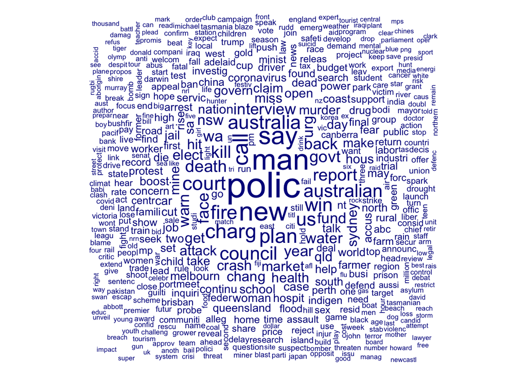

```r
library("quanteda.textplots")
textplot_wordcloud(news_dtm)
```

I was surprised to see words like powertwo, Darwin, Tasmania and not surprised by works liked jail,parliament, violence.

Let’s now do topic modeling. Make sure to load necessary packages via

```r
library("topicmodels")
library('tidytext')
```

# Question 14

```r
topMod <- convert(news_dtm, to = 'topicmodels')
topic_model <- LDA(topMod, method = "VEM", control = list(seed=1234), k=8)
terms(topic_model, 8)
```

```
##      Topic 1  Topic 2     Topic 3      Topic 4   Topic 5     Topic 6
## [1,] "man"    "polic"     "man"        "fire"    "say"       "polic"
## [2,] "nsw"    "win"       "murder"     "new"     "call"      "report"
## [3,] "fire"   "plan"      "face"       "man"     "man"       "talk"
## [4,] "mine"   "new"       "australian" "council" "new"       "cut"
## [5,] "attack" "australia" "report"     "say"     "plan"      "market"
## [6,] "polic"  "final"     "year"       "plan"    "australia" "win"
## [7,] "face"   "call"      "court"      "call"    "mine"      "fund"
## [8,] "open"   "job"       "cut"        "water"   "hous"      "charg"
##      Topic 7      Topic 8
## [1,] "jail"       "say"
## [2,] "make"       "new"
## [3,] "man"        "interview"
## [4,] "case"       "court"
## [5,] "court"      "back"
## [6,] "us"         "charg"
## [7,] "australian" "wa"
## [8,] "fund"       "man"
```

# Question 15

Plot betas of top 10 words with highest beta for each 8 topic. Comment on 3-4 news headline groups in terms of their topic content.

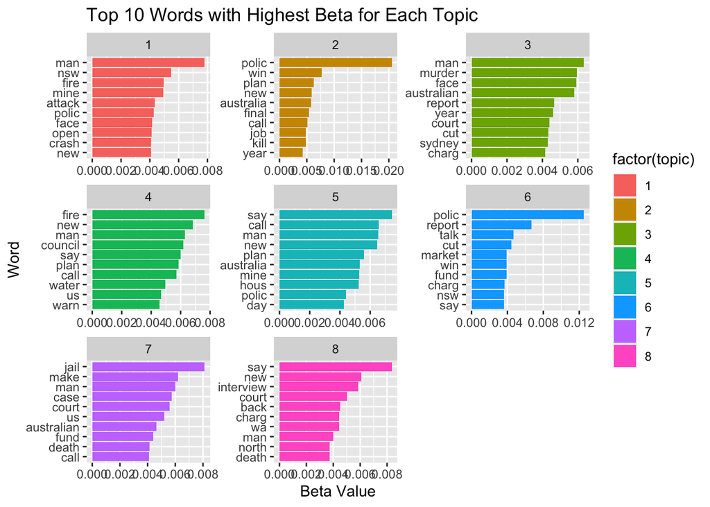

```r
library(reshape2)
topics <- tidy(topic_model, matrix = "beta")
topWords <- topics %>%
  group_by(topic) %>%
  slice_max(beta, n = 10) %>%
  ungroup() %>%
  arrange(topic, -beta)

topWords %>%
  mutate(term = reorder_within(term, beta, topic)) %>%
  ggplot(aes(beta, term, fill = factor(topic))) + geom_bar(stat = "identity") +
  geom_col(show.legend = FALSE) +
  labs(title = "Top 10 Words with Highest Beta for Each Topic", x = "Beta Value", y = "Word") +
  facet_wrap(~topic, scales = "free") +
  scale_y_reordered()
```

# Question 16

Plot gammas of top 5 documents with highest gamma for each 8 topic. Return the contents of the 5 documents with highest gamma only for topics 1 and 2. Does it makes sense that these documents are assigned to topics 1 and 2 accordingly? Comment.

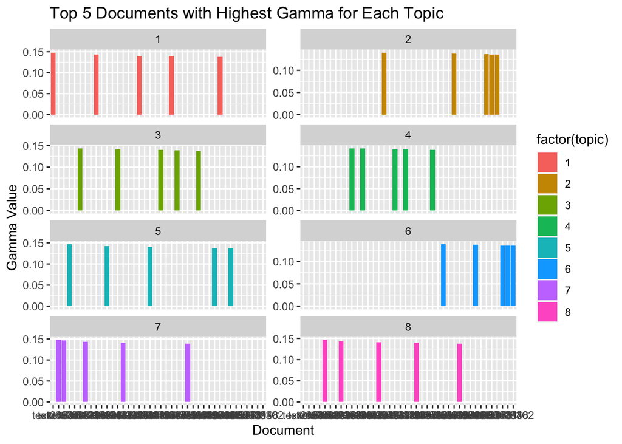

```r
gammaVal <- tidy(topic_model, matrix = "gamma")
documents <- gammaVal %>%
  group_by(topic) %>%
  slice_max(gamma, n = 5) %>%
  ungroup() %>%
  arrange(topic, -gamma)
ggplot(documents, aes(x = reorder(document, -gamma), y = gamma, fill = factor(topic)))  + geom_bar(stat = "identity") + labs(title = "Top 5 Documents with Highest Gamma for Each Topic",
       x = "Document", y = "Gamma Value") +
  facet_wrap(~topic, scales = "free_y", ncol = 2)
```

```r
topdocuments <- documents %>%
  filter(topic %in% c(1, 2))
print(topdocuments)
```

```
## # A tibble: 10 × 3
##    document topic gamma
##    <chr>    <int> <dbl>
##  1 text2163     1 0.148
##  2 text9780     1 0.143
##  3 text5717     1 0.140
##  4 text6379     1 0.140
##  5 text2197     1 0.138
##  6 text9203     2 0.140
##  7 text6697     2 0.138
##  8 text4387     2 0.137
##  9 text5768     2 0.136
## 10 text3731     2 0.136
```

Yes because each word under each topic are related or similar to one another and match headlines. It would make sense to assign them together under a topic.

You are done! 🏁 Don’t forget to commit and push your .Rmd file to your Github repository before the due date.